# Bikes

## by Scott Smith

This data set includes information about individual rides made in a bike-sharing system covering the greater San Francisco Bay area.

There are 453,159 records after cleaning up the original data. There are 15 different characteristics about the ride and the riders.

The duration of the ride (how long are the customers using the bikes?)

Which gender rides more often? What age group rides most often?

Are they regular riders (subscriber) or just occasional (customer).

The main characteristics to be investigated are - member gender, member birth year, user type and duration.

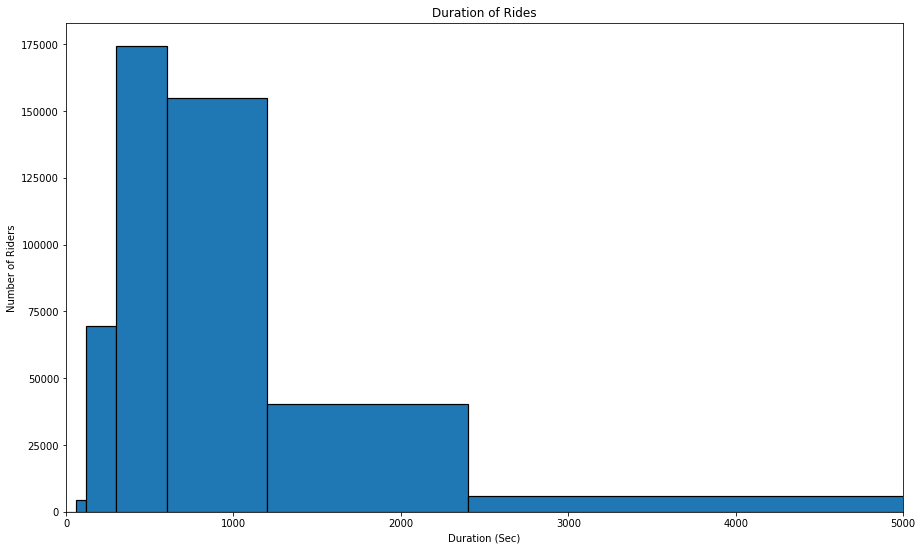

```python
x_values = [0, 60, 120, 300, 600, 1200, 2400, 6000, 10000]
#x_ticks = [round(x/60) for x in x_values]

plt.figure(figsize=[15, 9])
plt.hist(data = df_cleaned, x = 'duration_sec',  bins = x_values,
         edgecolor='black', linewidth=1.2)
plt.title('Duration of Rides')
plt.ylabel('Number of Riders')
plt.xlabel('Duration (Sec)')
#plt.xticks(x_values, x_ticks)
plt.xlim(0, 5000)
plt.show()
```

Because the duration distribution shows a skew to the right, with a few rides of a very long duration, I used a log scale. Plotted with a log scale, it shows to be unimodel and peaking between 500 to 900 seconds (roughly 10 minute rides, about a 1/4 of the rides).

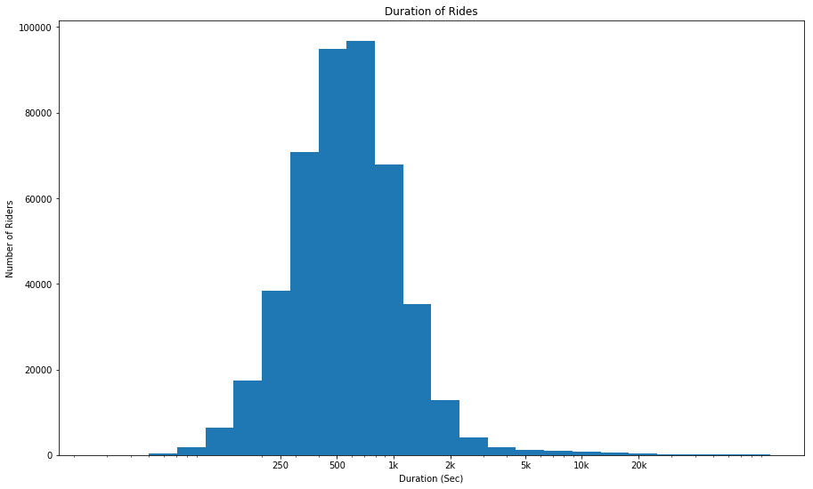

```python
log_binsize = .15
bins = 10 ** np.arange(1.4, np.log10(df_cleaned['duration_sec'].max())+log_binsize, log_binsize)

plt.figure(figsize=[15, 9])
plt.hist(data = df_cleaned, x = 'duration_sec', bins = bins)
plt.xscale('log')
plt.xticks([250, 500, 1e3, 2e3, 5e3, 1e4, 2e4], [250, 500, '1k', '2k', '5k', '10k', '20k'])
plt.title('Duration of Rides')
plt.ylabel('Number of Riders')
plt.xlabel('Duration (Sec)')
plt.show()
```

The graph shows an overwhelming number of Subscribers as compared to the random Customer. The gender of the riders also shows that there are many more male riders than female or other riders.

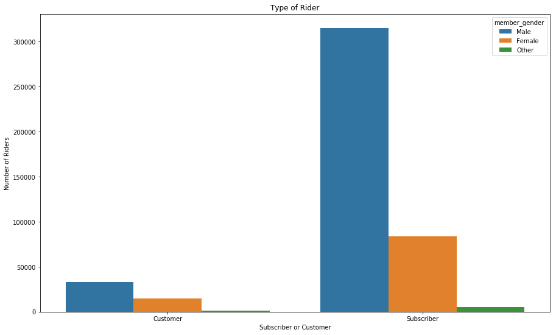

```python
plt.figure(figsize=[15, 9])
sb.countplot(data = df_cleaned, x = 'user_type', hue = 'member_gender')
plt.xlabel('Subscriber or Customer')
plt.ylabel('Number of Riders')
plt.title('Type of Rider');
```

While the majority of the birth years were early to mid 1980's, with early 1990's as the next level, there are considerably more male riders compared to female riders. The rides of longer duration; however, show a fairly even amount of males and females taking those longer rides.

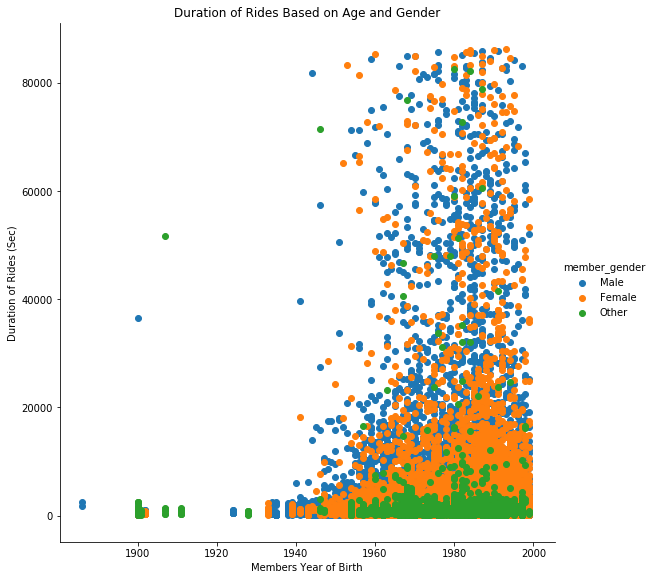

```python
g = sb.FacetGrid(data = df_cleaned, hue = 'member_gender', size = 8)
g.map(plt.scatter, 'member_birth_year','duration_sec')
g.set_xlabels('Members Year of Birth')
g.set_ylabels('Duration of Rides (Sec)')
plt.title('Duration of Rides Based on Age and Gender')
g.add_legend();
```